# soil respiration_incubation

Sistla, Seeta and Pold, Grace

2022-06-30

## Load required packages

load respiration data file (licor data and soil moisture, remove all blanks from soil moisture using ‘na.omit’) You must have completed gravimetric moisture before running this script, should be done in parallel with SIR your file should be identical in structure to the example data

```r
Respiration<- read_excel("biogeochem_example.xlsx",
                 sheet = "Basal_Respiration") [,1:13]
Soil_Moisture <- read_excel("biogeochem_example.xlsx",
                            sheet = "Soil_Moisture") [,c(1, 6:13)]

Soil_Moisture<-na.omit(Soil_Moisture)
```

```r
Respiration$Time2hrs<-ymd_hms(Respiration$Time2hrs)-ymd_hms(Respiration$TimeZero)
Respiration$Time4hrs<-ymd_hms(Respiration$Time4hrs)-ymd_hms(Respiration$TimeZero)
Respiration$TimeZero<-0
```

## separate out sample ID info, mass, hour, and ppm (respiration) for each time point. If more than three time points adjust accordingly. Then create one long form file with all time points for all samples (‘SIR_all’). Create unique ID for pseudoreplicates A and B

```r
Respiration0<-Respiration[,1:9]
Respiration2<-Respiration[,c(1:7, 10,11)]
Respiration4<-Respiration[,c(1:7, 12,13)]

names(Respiration2)<-names(Respiration0)
names(Respiration4)<-names(Respiration0)

Respiration_all<-rbind(Respiration0, Respiration2, Respiration4)
Respiration_all$uniqueID<-paste(Respiration_all$`Soil_ID`, Respiration_all$Pseudoreplicate, sep="_")
```

#gsub is what you want to replace with what you want to replace it #make an empty dataframe to put the regression fits for Co2 vs. time slopes in #[Number before the *] and ncol= should equal the number of columns on metadata on Respiration_all (everything except time & ppmCO2) + 4

```r
names(Respiration_all)<-gsub(" ", "_", names(Respiration_all))
outframe<-matrix(rep(NA, times=12*nrow(Respiration_all)/3), ncol = 12)
```

## Run loop to calculate respiration slope (CO2ppm /hr)

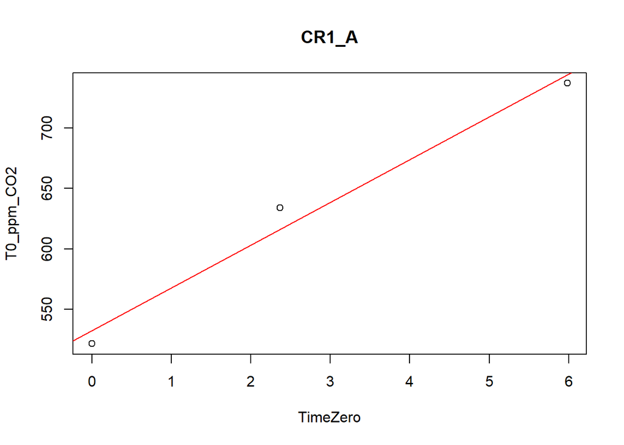

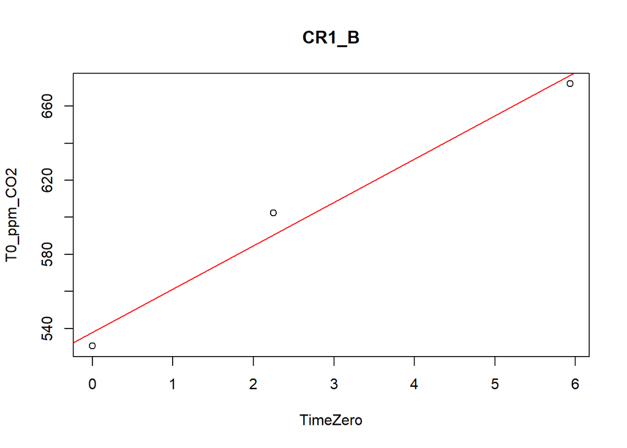

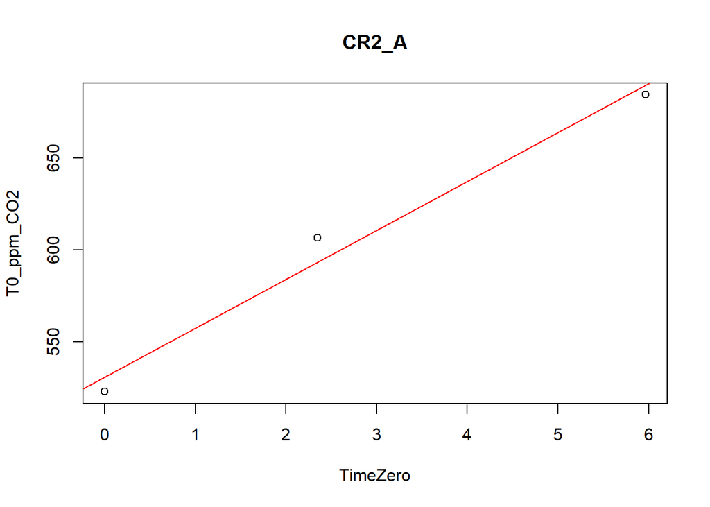

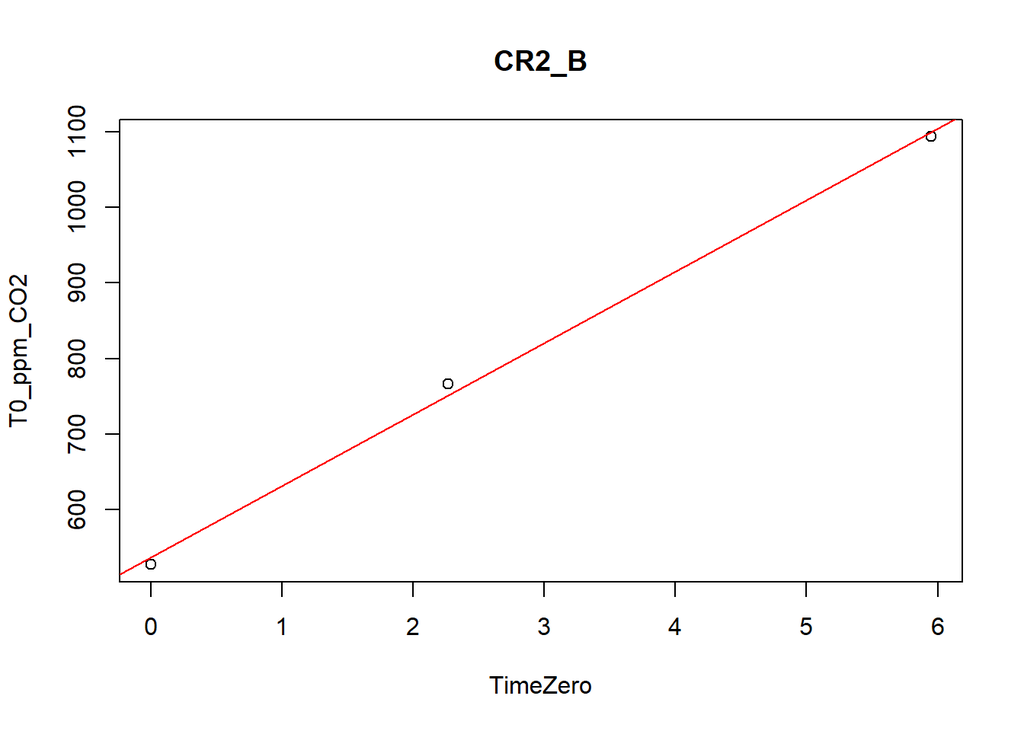

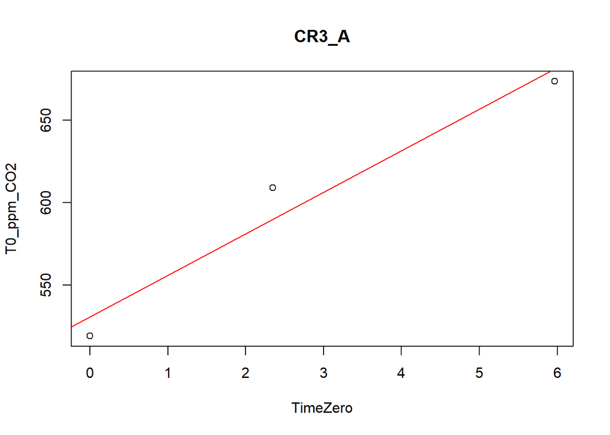

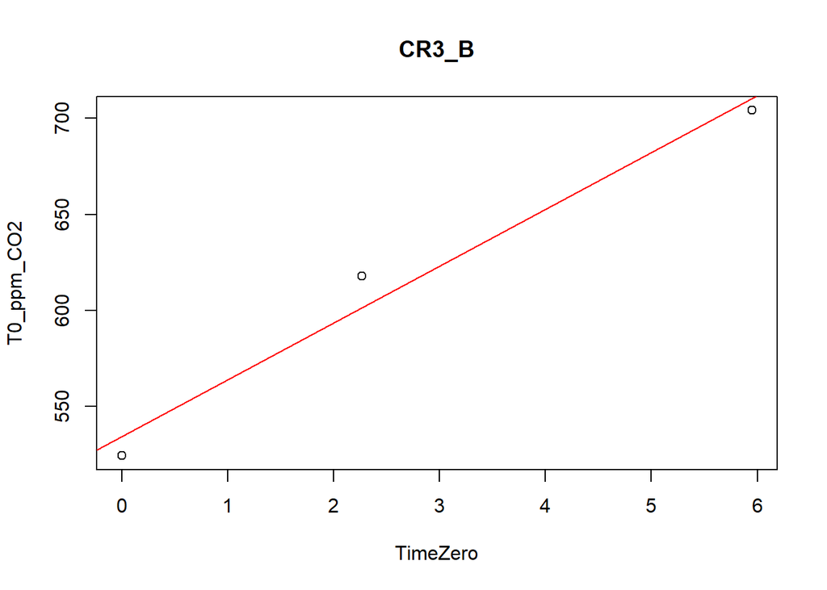

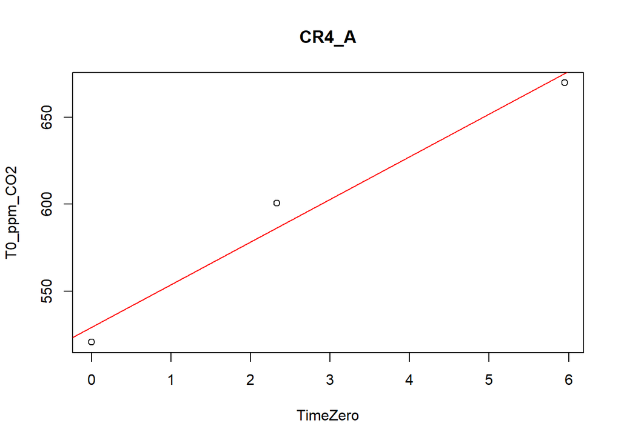

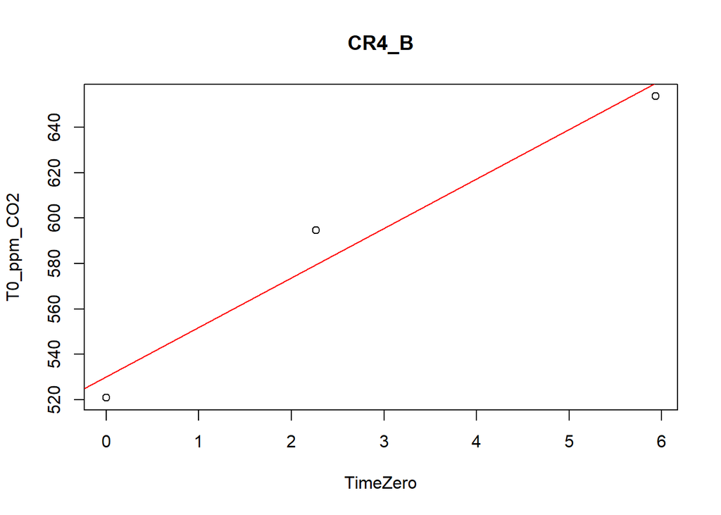

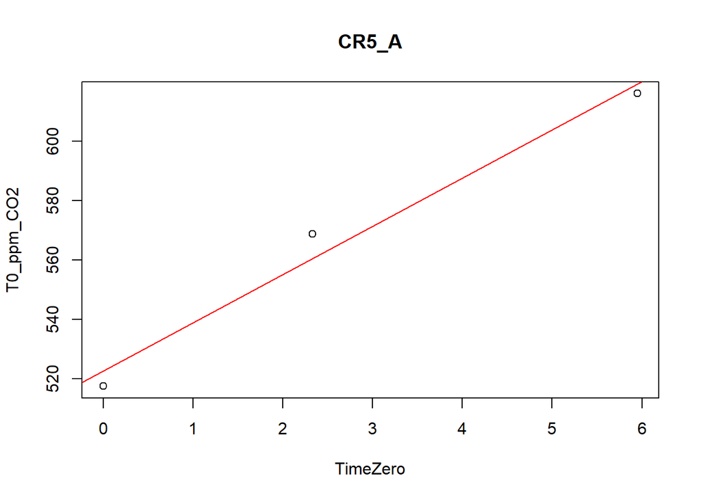

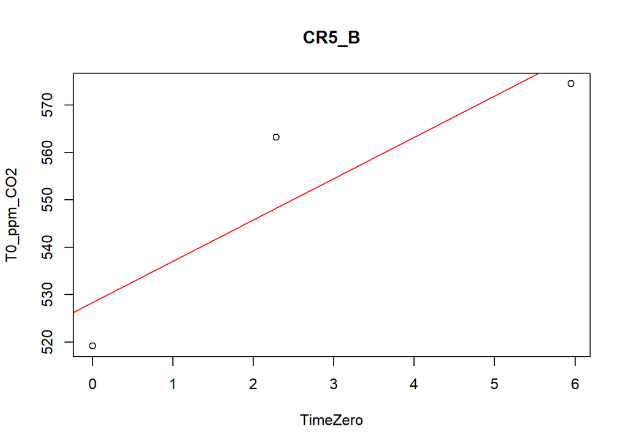

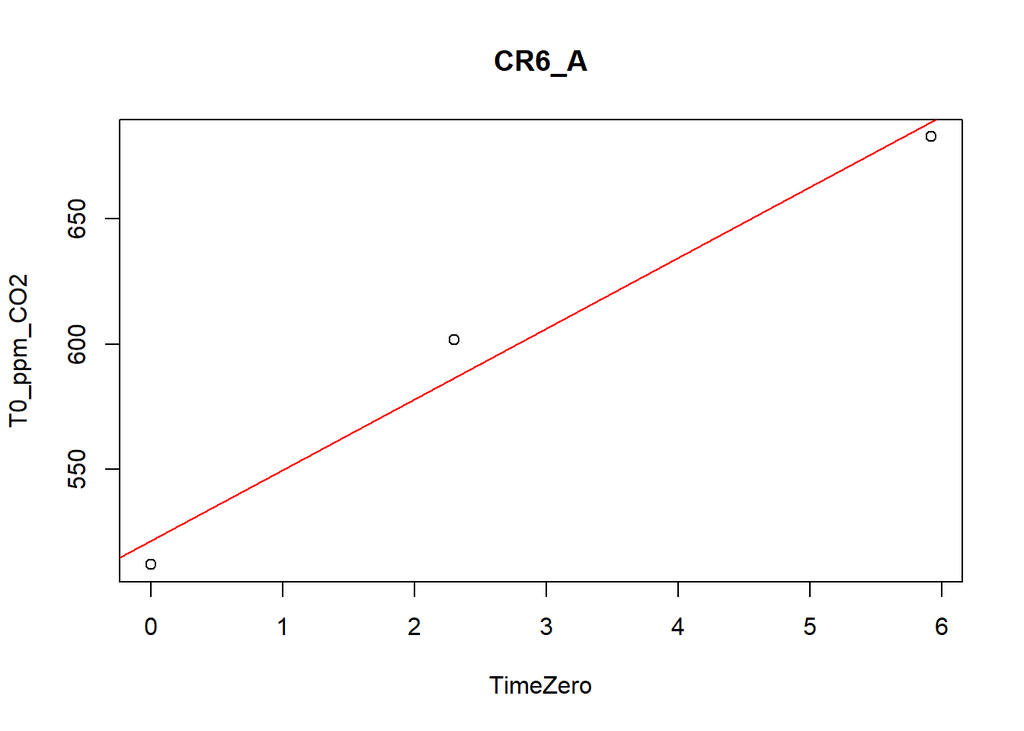

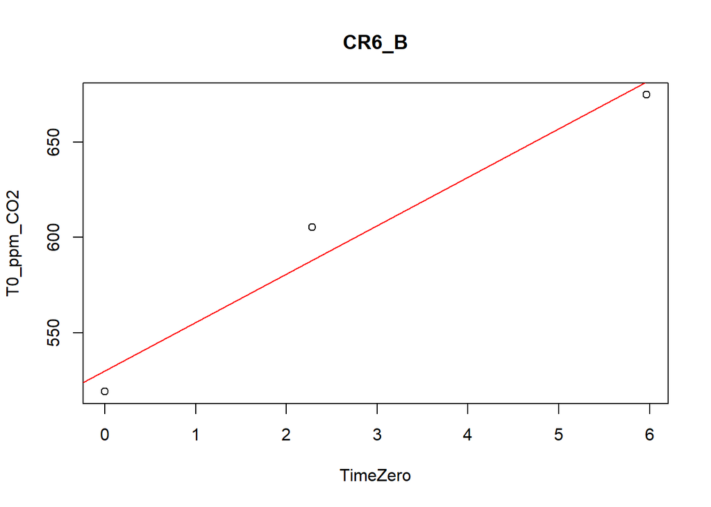

[40 more figures not shown]

```r
i<-1
for(sampleid in unique(Respiration_all$uniqueID)){
  datsub<-subset(Respiration_all, uniqueID==sampleid)#subsetting to get data just for sample of interest
  ModFit<-summary(lm(T0_ppm_CO2~TimeZero, datsub))#fit a linear model to determine slope
  outframe[i,]<- unlist(c(datsub[1,1:7], sampleid, ModFit$r.squared, ModFit$coefficients[2], ModFit$coefficients[4], ModFit$coefficients[8]))
  #extract the parameters of interest (ie slope, Rsq and p-values for slope) and save to a new dataframe
  plot(T0_ppm_CO2~TimeZero, data = datsub, main=sampleid)
  abline(lm(T0_ppm_CO2~TimeZero, data = datsub), col="red")
  i<-i+1
}
```

## name outframe data columns as labeled in metadata sheet, change columns to numeric or character as appropriate

```r
outframe<-as.data.frame(outframe) #Changes from a matrix to a data frame
names(outframe)<-c("Soil_ID", "Pseudoreplicate", "Block", "Plastic_Association", "Mulch_Thickness", "BDM_Maker", "Soil_wet_wt", "uniqueID", "r.squared", "slope", "SE", "slope_pval")
outframe[,c(7,9:12)]<- sapply(outframe[,c(7,9:12)],as.character)
outframe[,c(7,9:12)]<- sapply(outframe[,c(7,9:12)],as.numeric)
```

## QA/QC to remove linear relationships that are not strong (P value <0.2). Do not subtract out negative control, but check that CO2 level was not changing in a meanigful way (i.e, increasing with strong slope)!

#You should stop at this point and see how many reps are lost from yoru data, if remaining resp have reasonable slopes. It is good to QA/AC as data is collected

```r
outframe_good<-subset(outframe, slope_pval<=0.2)
```

#Divide slopes by wet soil weight divide by the dry/wet to get respiration per g dry soil per hr

# Convert from µM (ppm) to µg C-CO2

Assume 236.6 mls of volume (8fl oz jar) and the room was 20 ˚C, n*1000 (mmol air) = PV/RT This yields: [ (9.84*0.001*12) * ppm CO2]/ (dry weight soil* hr) YOU MUST CHANGE THE # 9.84 if using a different jar! convert to per day (*24 hours/day)

```r
outframe_good$slope_wetSoil<-outframe_good$slope/outframe_good$Soil_wet_wt

FinalRespiration<-merge(outframe_good,Soil_Moisture,by = "Soil_ID")
FinalRespiration$slope_wetsoil_hours<-FinalRespiration$slope_wetSoil
FinalRespiration$Dry_Respiration<-FinalRespiration$slope_wetsoil_hours/FinalRespiration$`Average_DryMass/WetMass`

FinalRespiration$ugC_CO2_gsoil_hr<-FinalRespiration$Dry_Respiration*9.84*0.001*12
FinalRespiration$ugC_CO2_gsoil_day<- FinalRespiration$ugC_CO2_gsoil_hr*24


final_ave_Respiration <- FinalRespiration %>%
  group_by(Soil_ID) %>%
  summarize(Respiration_ave_hr = mean(ugC_CO2_gsoil_hr), Respiration_ave_day = mean(ugC_CO2_gsoil_day)) %>%
  as.data.frame()
final_ave_Respiration
```

```
##    Soil_ID Respiration_ave_hr Respiration_ave_day
## 1      CR1          0.6770761           16.249827
## 2     CR10          0.4257084           10.217002
## 3     CR11          0.4548674           10.916817
## 4     CR12          0.3995839            9.590014
## 5     CR13          0.6545274           15.708657
## 6     CR14          0.3426678            8.224028
## 7     CR15          0.3846931            9.232633
## 8     CR16          0.4023585            9.656603
## 9     CR17          0.4774281           11.458275
## 10    CR18          0.4754076           11.409783
## 11    CR19          0.4192223           10.061336
## 12     CR2          1.4006000           33.614399
## 13    CR20          0.4409852           10.583646
## 14    CR21          0.6573036           15.775287
## 15    CR22          0.5467231           13.121355
## 16    CR23          1.0449927           25.079824
## 17    CR24          0.4486467           10.767521
## 18    CR25          0.7754650           18.611160
## 19     CR3          0.6374080           15.297792
## 20     CR4          0.5345381           12.828914
## 21     CR5          0.3787797            9.090713
## 22     CR6          0.6158826           14.781181
## 23     CR7          0.4824638           11.579130
## 24     CR8          0.4491962           10.780708
## 25     CR9          0.5036933           12.088640
```

#create unique ID (soilID_A) and adding to final_ave_sIR data frame, merge with ‘FinalSIR data frame that has all other relevant info, remove meaningles columns (’new col’ and ’Soil_ID which will be duplicated) ## write final SIR file

```r
replicate<- rep(c("A"), 25)

final_ave_Respiration<- final_ave_Respiration  %>%
  mutate(newcol = replicate)


final_ave_Respiration$uniqueID<-paste(final_ave_Respiration$`Soil_ID`, final_ave_Respiration$newcol, sep="_")
final_ave_Respiration<- select(final_ave_Respiration, -newcol)
final_ave_Respiration<- select(final_ave_Respiration, -Soil_ID)

FinalAveRespiration <- merge(FinalRespiration,final_ave_Respiration,by="uniqueID", all.x = TRUE)
write.csv(FinalAveRespiration, "FinalRespiration_EXAMPLE.csv")
```

#SIR Plot by plastic association

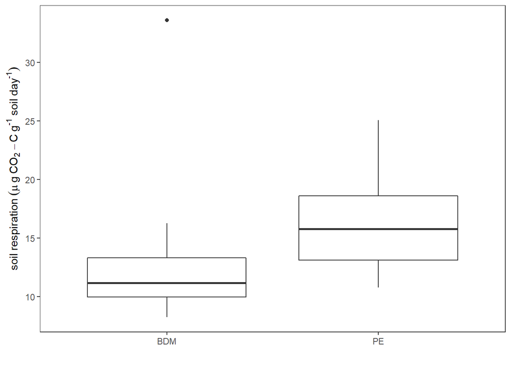

```r
Respirationplot<- ggplot(FinalAveRespiration, aes(x=Plastic_Association,y=Respiration_ave_day))+ geom_boxplot()+
  theme_bw() +
  theme(panel.grid = element_blank(), legend.position = "none")+
  labs(x = '', y = (expression(soil~respiration~(mu~g~CO[2]~-C~g^{"-1"}~soil~day^{"-1"}))))
Respirationplot
```

#Read back in data #Combine with metadata to fix 1.1 issue

FinalSIR<-read_excel(“FinalSIR_Corralitos.xlsx”)

meta<-read_excel(“Corralitos_Metadata_112021.xlsx”, sheet = “Metadata”, col_types = c(“text”, “numeric”, “text”, “numeric”, “text”)) FinalSIR<-merge(FinalSIR,meta, by = “Soil_ID”)